# Análise dos Dados da 9CaBer

**Objetivo**: Analisar os dados fornecidos para descobrir os melhores segmentos a serem usados para a próxima campanha da RankMyApp

## Vistoria Inicial da Fonte de Dados

**Fonte de Dados**: Os dados a serem utilizados pertencem ao aplicativo de Taxi 9CaBer, do período do mês de Maio de 2018

```python
#Importação das bibliotecas necessárias
import pandas as pd
import numpy as np
import matplotlib.pyplot as pt

%matplotlib inline
```

```python
#Importação do Arquivo CSV criado contendo os dados a serem analisados
taxi_app = pd.read_csv("Report_TaxiApp_2018-07-17.csv")

#Checagem dos valores iniciais dos dados importados
display(taxi_app.head())
print("Quantidade de Amostras: {0}. \tQuantidade de Atributos: {1}.".format(taxi_app.shape[0], taxi_app.shape[1]))
```

|  | Postback Timestamp | Click ID | Transaction ID | Country | Traffic Source ID | OS | Isp | Mobile Carrier | Connection Type | IP | Site ID |
| --- | --- | --- | --- | --- | --- | --- | --- | --- | --- | --- | --- |
| 0 | 5/31/18 23:56 | w9AJMV0C671MQ33EHLHVRH92 | install | Brazil | 9a2a1675-584d-491d-9fc9-aeaa674c6e2d | Android | Telefonica Brasil s.a. | Vivo | Mobile | 177,118,105,122 | 24138 |
| 1 | 5/31/18 23:55 | w2D5EHI6SH04BQAE1VRLD74O | install | Brazil | 5cff49a9-50d7-4272-917f-614a822124de | Android | Brasil Telecom Sa - Filial Distrito Federal | NaN | Xdsl | 201.89.13.176 | 7c0ajw76178_6761_652_60601652 |
| 2 | 5/31/18 23:25 | wFS5T9UIREPS4QAEHBURP7DG | first_ride | Brazil | 9a2a1675-584d-491d-9fc9-aeaa674c6e2d | Android | Claro Brazil | Claro | Mobile | 187.26.74.123 | 12088 |
| 3 | 5/31/18 23:22 | wDAIK3RD8OL0LQAEH6N197BG | install | Brazil | 9a2a1675-584d-491d-9fc9-aeaa674c6e2d | Android | Telefonica Brasil s.a. | NaN | Broadband | 201.86.248.165 | 12088 |
| 4 | 5/31/18 23:14 | wJH7VPPNE5G2SLAEHEHSBR68 | install | Brazil | 9a2a1675-584d-491d-9fc9-aeaa674c6e2d | Android | Telemar Norte Leste s.a. | NaN | Broadband | 186.247.61.28 | 26896 |

```
Quantidade de Amostras: 27199. 	Quantidade de Atributos: 11.
```

Os dados mostrados acima são apenas um breve resumo da quantidade total de dados a serem analisados, no caso *27199*. Com relação aos atributos presentes para esses dados, temos:

**Postback Timestamp**: Momento em que a conversão foi registrada.

**Click ID**: ID único para cada usuário registrado. Pode se repetir caso haja mais de um evento para um único usuário.

**Transaction ID**: Tipo de transação ou evento.

**Country**: País em que a conversão foi registrada.

**Traffic Source ID**: ID único de cada fonte de tráfego, sendo que *Fontes de tráfego* são os canais que veiculam a campanha e possuem um inventário único.

**OS**: Tipo de sistema operacional da conversão.

**Isp**: Operadora ou empresa provedora de internet.

**Mobile Carrier**: Operadora móvel.

**Connection Type**: Tipo de conexão utilizada (ex.: Wifi, 3G, etc).

**IP**: IP registrado no momento da conversão.

**Site ID**: ID único para cada site disponível no inventário de cada fonte de tráfego.

Agora, será apresentado os tipos de cada coluna. Esse método permite o conhecimento do tipo de dado armazenado em cada coluna, podendo assim ser cada coluna analisada de acordo com o mesmo:

```python
#Método para verificar os tipos das colunas:
for column in taxi_app.columns:
        print("coluna: {0}, tipo: {1}.\n".format(column, type(taxi_app[column][1])))
```

```
coluna: Postback Timestamp, tipo: <class 'str'>.

coluna: Click ID, tipo: <class 'str'>.

coluna: Transaction ID, tipo: <class 'str'>.

coluna: Country, tipo: <class 'str'>.

coluna: Traffic Source ID, tipo: <class 'str'>.

coluna: OS, tipo: <class 'str'>.

coluna: Isp, tipo: <class 'str'>.

coluna: Mobile Carrier, tipo: <class 'float'>.

coluna: Connection Type, tipo: <class 'str'>.

coluna: IP, tipo: <class 'str'>.

coluna: Site ID, tipo: <class 'str'>.
```

Portanto, com exceção da coluna **Mobile Carrier**, todas as colunas são do tipo *String*, ou seja *Texto*.

## Tratamento de Dados

Nesse tópico ocorrerá a passagem do conjunto de dados e sua verificação por condições que possam impedir sua efetiva e completa análise.

Inicialmente, será verificada a existência de *Valores Nulos* nos atributos do Conjunto de Dados:

```python
#Método para Verificar Quantidade de Valores Totais de um Conjunto em relação ao Total de Dados Nõa-Nulos em um Atributo:
print("Quantidade Total de Amostras: {0}\n\n".format(taxi_app.shape[0]))
for column in taxi_app.columns:
    print("Total de Valores Não-Nulos na Coluna {0}: {1}.\n".format(column, taxi_app[column].count()))
```

```
Quantidade Total de Amostras: 27199


Total de Valores Não-Nulos na Coluna Postback Timestamp: 27199.

Total de Valores Não-Nulos na Coluna Click ID: 27199.

Total de Valores Não-Nulos na Coluna Transaction ID: 27199.

Total de Valores Não-Nulos na Coluna Country: 27198.

Total de Valores Não-Nulos na Coluna Traffic Source ID: 27199.

Total de Valores Não-Nulos na Coluna OS: 27199.

Total de Valores Não-Nulos na Coluna Isp: 27195.

Total de Valores Não-Nulos na Coluna Mobile Carrier: 7360.

Total de Valores Não-Nulos na Coluna Connection Type: 27199.

Total de Valores Não-Nulos na Coluna IP: 27199.

Total de Valores Não-Nulos na Coluna Site ID: 27189.
```

Conforme visto pelo texto acima, as colunas **Country**, **Isp**, **Mobile Carrier** e **Site ID** tem valores não-nulos menores que o total de amostras presentes, concluindo que estas possuem valores nulos:

```python
taxi_app.isna().sum()
```

```
Postback Timestamp        0
Click ID                  0
Transaction ID            0
Country                   1
Traffic Source ID         0
OS                        0
Isp                       4
Mobile Carrier        19839
Connection Type           0
IP                        0
Site ID                  10
dtype: int64
```

Desses atributos contendo valores nulos, a maior quantidade deles reside em **Mobile Carrier**. Por possuir essa grande quantidade de valores nulos, prejudicando os demais atributos ao retirá-los do conjunto de dados, essa coluna não será utilizada para a análise dos dados:

```python
#Remoção da Coluna Mobile Carrier do Dataset
taxi_app_antigo = taxi_app
taxi_app = taxi_app.drop(["Mobile Carrier"], axis = 1)
display(taxi_app.head())
```

|  | Postback Timestamp | Click ID | Transaction ID | Country | Traffic Source ID | OS | Isp | Connection Type | IP | Site ID |
| --- | --- | --- | --- | --- | --- | --- | --- | --- | --- | --- |
| 0 | 5/31/18 23:56 | w9AJMV0C671MQ33EHLHVRH92 | install | Brazil | 9a2a1675-584d-491d-9fc9-aeaa674c6e2d | Android | Telefonica Brasil s.a. | Mobile | 177,118,105,122 | 24138 |
| 1 | 5/31/18 23:55 | w2D5EHI6SH04BQAE1VRLD74O | install | Brazil | 5cff49a9-50d7-4272-917f-614a822124de | Android | Brasil Telecom Sa - Filial Distrito Federal | Xdsl | 201.89.13.176 | 7c0ajw76178_6761_652_60601652 |
| 2 | 5/31/18 23:25 | wFS5T9UIREPS4QAEHBURP7DG | first_ride | Brazil | 9a2a1675-584d-491d-9fc9-aeaa674c6e2d | Android | Claro Brazil | Mobile | 187.26.74.123 | 12088 |
| 3 | 5/31/18 23:22 | wDAIK3RD8OL0LQAEH6N197BG | install | Brazil | 9a2a1675-584d-491d-9fc9-aeaa674c6e2d | Android | Telefonica Brasil s.a. | Broadband | 201.86.248.165 | 12088 |
| 4 | 5/31/18 23:14 | wJH7VPPNE5G2SLAEHEHSBR68 | install | Brazil | 9a2a1675-584d-491d-9fc9-aeaa674c6e2d | Android | Telemar Norte Leste s.a. | Broadband | 186.247.61.28 | 26896 |

Com esse atributo retirado do conjunto, será analisado os valores nulos restantes.

Na Coluna **Country**, por ter apenas um valor nulo, pode-se tanto retirar essa tupla, ou seja linha do conjunto de dados, quanto acrescentar em seu lugar o texto com maior frequência dentro desse atributo:

```python
print("Países presentes nesse Conjunto de Dados: {0}\n".format(taxi_app["Country"].unique()))
print("Total de Países presentes: {0}.".format(taxi_app["Country"].nunique()))
```

```
Países presentes nesse Conjunto de Dados: ['Brazil' 'United States' 'Spain' 'Mexico' 'Argentina' 'Peru' 'Paraguay'
 'Ecuador' 'Portugal' 'Colombia' 'France' 'Costa Rica' nan]

Total de Países presentes: 12.
```

```python
#Verificação da média de valores presentes na coluna Country
taxi_app["Country"].describe()
```

```
count      27198
unique        12
top       Brazil
freq       27080
Name: Country, dtype: object
```

Com isso, foi descoberto que *Brazil* é o país com maior ocorrência de frequência ao longo dos dados. Portanto, será adicionado ao lugar do valor nulo:

```python
#Preenchendo o Valor Nulo da coluna Country pelo texto "Brazil"
taxi_app['Country'].fillna("Brazil", inplace=True)
print("Países presentes nesse Conjunto de Dados: {0}\n".format(taxi_app["Country"].unique()))
print("Total de Valores Não-Nulos: {0}".format(taxi_app["Country"].count()))
```

```
Países presentes nesse Conjunto de Dados: ['Brazil' 'United States' 'Spain' 'Mexico' 'Argentina' 'Peru' 'Paraguay'
 'Ecuador' 'Portugal' 'Colombia' 'France' 'Costa Rica']

Total de Valores Não-Nulos: 27199
```

Ainda é necessário a limpeza dos dados nulos de **Site ID**:

```python
print("Total de Sites ID presentes: {0}.".format(taxi_app["Site ID"].nunique()))
```

```
Total de Sites ID presentes: 568.
```

```python
taxi_app["Site ID"].describe()
```

```
count     27189
unique      568
top       12088
freq       4575
Name: Site ID, dtype: object
```

Como esse atributo possui um dado de maior frequência, coloca-se o mesmo nos valores nulos:

```python
taxi_app["Site ID"].fillna("12088", inplace=True)
print("Total de Valores Nulos em Site ID: {0}".format(taxi_app["Site ID"].isna().sum()))
```

```
Total de Valores Nulos em Site ID: 0
```

Por último, têm-se a limpeza de dados de **Isp**:

```python
print("Total de Operadoras presentes: {0}.".format(taxi_app["Isp"].nunique()))
```

```
Total de Operadoras presentes: 2129.
```

```python
taxi_app["Isp"].describe()
```

```
count            27195
unique            2129
top       Claro Brazil
freq              6997
Name: Isp, dtype: object
```

Portanto, ocorre a inserção do dado de maior frequência nos valores nulos:

```python
taxi_app["Isp"].fillna("Claro Brazil", inplace=True)
print("Total de Valores Nulos em Isp: {0}".format(taxi_app["Isp"].isna().sum()))
```

```
Total de Valores Nulos em Isp: 0
```

```python
print("Total de Dados Não-Nulos no conjunto:\n\n{0}".format(taxi_app.count()))
```

```
Total de Dados Não-Nulos no conjunto:

Postback Timestamp    27199
Click ID              27199
Transaction ID        27199
Country               27199
Traffic Source ID     27199
OS                    27199
Isp                   27199
Connection Type       27199
IP                    27199
Site ID               27199
dtype: int64
```

Logo, não há mais valores nulos no Dataset, ou seja, o Conjunto de Dados.

Por fim da limpeza de dados, será verificada a existência de valores duplicados no Dataset:

```python
#Método para verificar se há valores duplicados no dataset
def duplicado(df):
    if df.duplicated().any():
        print("Possui {0} valores duplicados".format(df.duplicated().sum()))
    else:
        print("Não possui valores duplicados")

duplicado(taxi_app)
```

```
Não possui valores duplicados
```

Portanto, não há a presença de valores duplicados nos dados a serem analisados.

## Análise dos Dados Tratados

Agora, ocorrerá a análise dos dados tratados através da inferência estatística.

### Breve Descrição das Estratégias de Aquisições Pagas

Primeiramente será deixado claro alguns conceitos de critério de **Estratégia de Aquisições Pagas**, tendo em vista que foi esse a forma de marketing escolhida pela empresa cujo os dados serão analisados. Essa breve descrição tem por objetivo classificar corretamente o tipo de aquisição no qual a empresa poderia ter um melhor retorno acerca de seu produto, bem como utilizá-lo na análise dos tipos de atributos presentes em seus dados.

De acordo com as informações oficiais da [RankMyApp](https://www.rankmyapp.com/pt-br/solucoes/aquisicoes-pagas/), no tópico **Aquisição Paga de Usuários** têm-se três tipos:

**Custos da Publicação por Mil(CPM)**: Nessa estratégia, recomendada por aplicativos com *um potencial em um período determinado, principalmente por causa de um evento específico*, é utilizado a cobrança pelo número de impressões do post do mesmo em uma rede social, sendo essa estratégia vantajosa para investimentos em *Custos por Clique*.

**Custo por Ação(CPA)**:já nessa estratégia é necessário que *o usuário faça também um pré-cadastro, ou entre em contato, e não apenas clique no produto*, para que seja efetuado a cobrança do mesmo. Portanto, a cobrança é efetuada através de *uma ação específica realizada pelo usuário com seu produto*.

**Custo por Instalação(CPI)**: Utilizado principalmente pela área de *Mobile Marketing*, nessa estratégica, sendo necessário a *interação direta com o público-alvo por parte da empresa contratante*, principalmente para apresentá-los os motivos pelos quais o público deve consumir seu produto, a cobrança ocorre por meio dos downloads feitos pelos usuários. Para isso, é necessário *decidir precisamente qual público o seu aplicativo quer atingir com essa ação*.

Portanto, para a empresa 9CaBer, é necessário usar a estratégia **Custo por Instalação**. Porém, pode-se também ser utilizado **Custo por Ação**, tendo em vista que, por ser um aplicativo de taxi, é necessário o cadastro dos usuários, bem como o início das corridas para que tal aplicativo exerca seu objetivo.

Primeiramente é preciso saber a quantidade de valores únicos em cada atributo:

```python
#Criando um método para a conversão dos dados únicos para a geração de gráficos:
def padrao_colunas(atributo):
    labels = [x for x in range(0, taxi_app[atributo].nunique())]
    return (labels)
```

```python
for column in taxi_app.columns:
    print("Total de valores únicos em {0}: {1}.".format(column, taxi_app[column].nunique()))
```

```
Total de valores únicos em Postback Timestamp: 14355.
Total de valores únicos em Click ID: 26241.
Total de valores únicos em Transaction ID: 3.
Total de valores únicos em Country: 12.
Total de valores únicos em Traffic Source ID: 14.
Total de valores únicos em OS: 5.
Total de valores únicos em Isp: 2129.
Total de valores únicos em Connection Type: 7.
Total de valores únicos em IP: 24124.
Total de valores únicos em Site ID: 568.
```

Como existem valores com uma grande quantidade de dados diferentes em alguns atributos, uma das melhores opções de comparação é utilizar os atributos que possuem os menores números de dados diferentes, garantindo uma comparação mais limpa e de fácil entendimento. Portanto, serão usados de base comparativa os atributos **Transaction ID**, **Country**, **Traffic Source ID**, **OS** e **Connection Type**. Além disso, para melhor visualização gráfica, será utilizada o atributo **Click ID** como eixo vertical.

Inicialmente será analisado os dados do atributo **Country**, sendo apresentados novamente a seguir:

```python
#Amostragem dos Países
taxi_app.groupby(["Country"]).count()
```

| Country | Postback Timestamp | Click ID | Transaction ID | Traffic Source ID | OS | Isp | Connection Type | IP | Site ID |
| --- | --- | --- | --- | --- | --- | --- | --- | --- | --- |
| Argentina | 4 | 4 | 4 | 4 | 4 | 4 | 4 | 4 | 4 |
| Brazil | 27081 | 27081 | 27081 | 27081 | 27081 | 27081 | 27081 | 27081 | 27081 |
| Colombia | 8 | 8 | 8 | 8 | 8 | 8 | 8 | 8 | 8 |
| Costa Rica | 1 | 1 | 1 | 1 | 1 | 1 | 1 | 1 | 1 |
| Ecuador | 7 | 7 | 7 | 7 | 7 | 7 | 7 | 7 | 7 |
| France | 1 | 1 | 1 | 1 | 1 | 1 | 1 | 1 | 1 |
| Mexico | 4 | 4 | 4 | 4 | 4 | 4 | 4 | 4 | 4 |
| Paraguay | 4 | 4 | 4 | 4 | 4 | 4 | 4 | 4 | 4 |
| Peru | 8 | 8 | 8 | 8 | 8 | 8 | 8 | 8 | 8 |
| Portugal | 1 | 1 | 1 | 1 | 1 | 1 | 1 | 1 | 1 |
| Spain | 2 | 2 | 2 | 2 | 2 | 2 | 2 | 2 | 2 |
| United States | 78 | 78 | 78 | 78 | 78 | 78 | 78 | 78 | 78 |

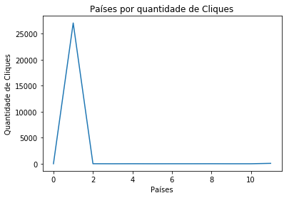

```python
#Criação do Gráfico de Países com relação à quantidade de Cliques
country = taxi_app.groupby(["Country"], as_index=True)["Click ID"].count()
country_labels = padrao_colunas("Country")
country_data = dict(zip(country_labels,country.keys()))
pt.plot(country_labels, country.get_values());
pt.title("Países por quantidade de Cliques");
pt.xlabel("Países");
pt.ylabel("Quantidade de Cliques");
```

```python
#Amostragem da legenda dos Valores do eixo X
print("Legenda dos Valores:")
for i in country_data:
    print("Índice {0}: País {1}.".format(i, country_data[i]))
```

```
Legenda dos Valores:
Índice 0: País Argentina.
Índice 1: País Brazil.
Índice 2: País Colombia.
Índice 3: País Costa Rica.
Índice 4: País Ecuador.
Índice 5: País France.
Índice 6: País Mexico.
Índice 7: País Paraguay.
Índice 8: País Peru.
Índice 9: País Portugal.
Índice 10: País Spain.
Índice 11: País United States.
```

Com base nos dados de contagem e no gráfico acima, pode-se concluir que o país que possui a maior parte dos acessos ao produto é o *Brazil*, seguido de *United States*. Porém, tem países com baixíssimos acessos, como *Portugal* e *Costa Rica*, com apenas um acesso cada. O ideal seria uma maior campanha especialmente em países com menor número de acessos. Portanto, o atributo **Country** pode ser um fato significativo para a criação da próxima campanha.

Agora, será analisado o atributo **Transaction ID**:

```python
#Amostragem dos tipos de Transações realizadas
taxi_app.groupby(["Transaction ID"]).count()
```

| Transaction ID | Postback Timestamp | Click ID | Country | Traffic Source ID | OS | Isp | Connection Type | IP | Site ID |
| --- | --- | --- | --- | --- | --- | --- | --- | --- | --- |
| card_added | 1005 | 1005 | 1005 | 1005 | 1005 | 1005 | 1005 | 1005 | 1005 |
| first_ride | 693 | 693 | 693 | 693 | 693 | 693 | 693 | 693 | 693 |
| install | 25501 | 25501 | 25501 | 25501 | 25501 | 25501 | 25501 | 25501 | 25501 |

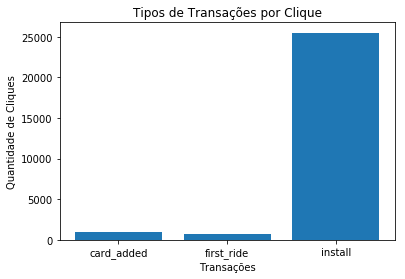

```python
#Criação do gráfico de Tipos de Transações por Cliques
transaction = taxi_app.groupby(["Transaction ID"])["Click ID"].count()
pt.bar(transaction.keys(), transaction.get_values());
pt.title("Tipos de Transações por Clique");
pt.xlabel("Transações");
pt.ylabel("Quantidade de Cliques");
```

A maioria das Transações realizadas ocorreram em média por *Install*, seguido por *Card_Added* e *First_Ride*, respectivamente. A quantidade de dados com relação às *Novas Instalações*, no caso *Install*, comprova a necessidade do uso da estratégia de **Custo por Instalação**, por ser um método de alto uso pelos usuários. Porém, ainda há usuários que realizaram o cadastro de novos cartões de crédito

Será feito agora uma comparação dos tipos de transações mais utilizados pelos países:

```python
#Amostragem dos Tipos de Sistemas Operacionais em relação aos Países
taxi_app.groupby(["Country", "Transaction ID"]).count()
```

| Country | Transaction ID | Postback Timestamp | Click ID | Traffic Source ID | OS | Isp | Connection Type | IP | Site ID |
| --- | --- | --- | --- | --- | --- | --- | --- | --- | --- |
| Argentina | install | 4 | 4 | 4 | 4 | 4 | 4 | 4 | 4 |
| Brazil | card_added | 979 | 979 | 979 | 979 | 979 | 979 | 979 | 979 |
|  | first_ride | 671 | 671 | 671 | 671 | 671 | 671 | 671 | 671 |
|  | install | 25431 | 25431 | 25431 | 25431 | 25431 | 25431 | 25431 | 25431 |
| Colombia | install | 8 | 8 | 8 | 8 | 8 | 8 | 8 | 8 |
| Costa Rica | install | 1 | 1 | 1 | 1 | 1 | 1 | 1 | 1 |
| Ecuador | card_added | 1 | 1 | 1 | 1 | 1 | 1 | 1 | 1 |
|  | first_ride | 1 | 1 | 1 | 1 | 1 | 1 | 1 | 1 |
|  | install | 5 | 5 | 5 | 5 | 5 | 5 | 5 | 5 |
| France | install | 1 | 1 | 1 | 1 | 1 | 1 | 1 | 1 |
| Mexico | card_added | 1 | 1 | 1 | 1 | 1 | 1 | 1 | 1 |
|  | install | 3 | 3 | 3 | 3 | 3 | 3 | 3 | 3 |
| Paraguay | install | 4 | 4 | 4 | 4 | 4 | 4 | 4 | 4 |
| Peru | card_added | 1 | 1 | 1 | 1 | 1 | 1 | 1 | 1 |
|  | install | 7 | 7 | 7 | 7 | 7 | 7 | 7 | 7 |
| Portugal | install | 1 | 1 | 1 | 1 | 1 | 1 | 1 | 1 |
| Spain | install | 2 | 2 | 2 | 2 | 2 | 2 | 2 | 2 |
| United States | card_added | 23 | 23 | 23 | 23 | 23 | 23 | 23 | 23 |
|  | first_ride | 21 | 21 | 21 | 21 | 21 | 21 | 21 | 21 |
|  | install | 34 | 34 | 34 | 34 | 34 | 34 | 34 | 34 |

De acordo com a tabela acima, apenas três países possuem os três tipos de transações realizadas: *Brazil*, *Ecuador* e *United States*. Enquanto que os restantes tem apenas o *Mexico* e *Peru* possui dois tipos de transações, sendo *Card_Added* e *Install*. A maioria do tipo de transação sendo de *Instalação* permite um desenvolvimento maior desse aspecto por parte da empresa do aplicativo, através de um aplicativo mais "leve", por exemplo, permitindo maiores adeptos a esse meio. Porém, transações por *Adições Novas de Cartões de Crédito* simbolizam um aumento maior na confiabilidade por parte dos usuários pelo aplicativo, portanto seria interessante investir nesse tipo de transação também.

Logo, o atributo **Transation ID**, principalmente analisado com **Country**, é considerado importante para a elaboração da próxima campanha.

Ainda também, há o atributo **OS** a ser analisado:

```python
#Amostragem dos tipos de Transações realizadas
taxi_app.groupby(["OS"]).count()
```

| OS | Postback Timestamp | Click ID | Transaction ID | Country | Traffic Source ID | Isp | Connection Type | IP | Site ID |
| --- | --- | --- | --- | --- | --- | --- | --- | --- | --- |
| Android | 26671 | 26671 | 26671 | 26671 | 26671 | 26671 | 26671 | 26671 | 26671 |
| IOS | 402 | 402 | 402 | 402 | 402 | 402 | 402 | 402 | 402 |
| Other desktop OS | 75 | 75 | 75 | 75 | 75 | 75 | 75 | 75 | 75 |
| RIM OS | 1 | 1 | 1 | 1 | 1 | 1 | 1 | 1 | 1 |
| Windows | 50 | 50 | 50 | 50 | 50 | 50 | 50 | 50 | 50 |

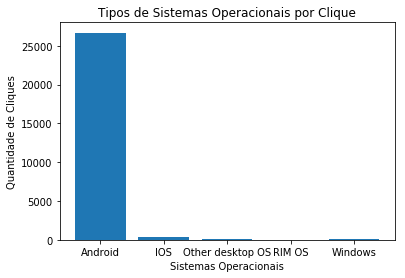

```python
#Criação do gráfico de Sistemas Operacionais por Cliques
os = taxi_app.groupby(["OS"])["Click ID"].count()
pt.bar(os.keys(), os.get_values());
pt.title("Tipos de Sistemas Operacionais por Clique");
pt.xlabel("Sistemas Operacionais");
pt.ylabel("Quantidade de Cliques");
```

A maioria dos Sistemas Operacionais utilizados são *Sistemas Mobile*, sendo o principal o **Sistema Android**, seguido do **IOS**.

Será visto a seguir a comparação dos tipos de Sistemas Operacionais com os países que os utilizam:

```python
#Amostragem dos Tipos de Sistemas Operacionais em relação aos Países
taxi_app.groupby(["Country", "OS"]).count()
```

| Country | OS | Postback Timestamp | Click ID | Transaction ID | Traffic Source ID | Isp | Connection Type | IP | Site ID |
| --- | --- | --- | --- | --- | --- | --- | --- | --- | --- |
| Argentina | Android | 4 | 4 | 4 | 4 | 4 | 4 | 4 | 4 |
| Brazil | Android | 26553 | 26553 | 26553 | 26553 | 26553 | 26553 | 26553 | 26553 |
|  | IOS | 402 | 402 | 402 | 402 | 402 | 402 | 402 | 402 |
|  | Other desktop OS | 75 | 75 | 75 | 75 | 75 | 75 | 75 | 75 |
|  | RIM OS | 1 | 1 | 1 | 1 | 1 | 1 | 1 | 1 |
|  | Windows | 50 | 50 | 50 | 50 | 50 | 50 | 50 | 50 |
| Colombia | Android | 8 | 8 | 8 | 8 | 8 | 8 | 8 | 8 |
| Costa Rica | Android | 1 | 1 | 1 | 1 | 1 | 1 | 1 | 1 |
| Ecuador | Android | 7 | 7 | 7 | 7 | 7 | 7 | 7 | 7 |
| France | Android | 1 | 1 | 1 | 1 | 1 | 1 | 1 | 1 |
| Mexico | Android | 4 | 4 | 4 | 4 | 4 | 4 | 4 | 4 |
| Paraguay | Android | 4 | 4 | 4 | 4 | 4 | 4 | 4 | 4 |
| Peru | Android | 8 | 8 | 8 | 8 | 8 | 8 | 8 | 8 |
| Portugal | Android | 1 | 1 | 1 | 1 | 1 | 1 | 1 | 1 |
| Spain | Android | 2 | 2 | 2 | 2 | 2 | 2 | 2 | 2 |
| United States | Android | 78 | 78 | 78 | 78 | 78 | 78 | 78 | 78 |

Com exceção do *Brazil*, todos os outros países utilizam o *Android* como sistema operacional padrão para o acesso ao aplicativo, mostrando a importância do aplicativo na versão *Mobile* do ponto de vista mundial. Essa importância poderia ser considerada um foco maior para o sistema *Android* no quesito de melhorias da plataforma, focado no *Mobile*.

Portanto, o atributo **OS** pode ser considerado um importante atributo a ser utilizado na próxima campanha.

Agora, será analisado o atributo **Connection Type**:

```python
#Amostragem dos tipos de Transações realizadas
taxi_app.groupby(["Connection Type"]).count()
```

| Connection Type | Postback Timestamp | Click ID | Transaction ID | Country | Traffic Source ID | OS | Isp | IP | Site ID |
| --- | --- | --- | --- | --- | --- | --- | --- | --- | --- |
| Broadband | 19307 | 19307 | 19307 | 19307 | 19307 | 19307 | 19307 | 19307 | 19307 |
| Cable | 13 | 13 | 13 | 13 | 13 | 13 | 13 | 13 | 13 |
| Dialup | 78 | 78 | 78 | 78 | 78 | 78 | 78 | 78 | 78 |
| Mobile | 7362 | 7362 | 7362 | 7362 | 7362 | 7362 | 7362 | 7362 | 7362 |
| Satellite | 32 | 32 | 32 | 32 | 32 | 32 | 32 | 32 | 32 |
| Wireless | 17 | 17 | 17 | 17 | 17 | 17 | 17 | 17 | 17 |
| Xdsl | 390 | 390 | 390 | 390 | 390 | 390 | 390 | 390 | 390 |

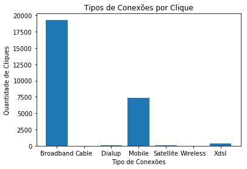

```python
#Criação dos tipos de conexões por Cliques
connection = taxi_app.groupby(["Connection Type"])["Click ID"].count()
pt.bar(connection.keys(),connection.get_values());
pt.title("Tipos de Conexões por Clique");
pt.xlabel("Tipo de Conexões");
pt.ylabel("Quantidade de Cliques");
```

Nesse aspecto, a maior parte dos usuários utilizam a **Internet Banda Larga**, ou **Broadband**, como tipo de conexão para o acesso ao serviço, seguido da **Internet de Celular**, ou **Mobile**, e **Conexões XDSI**, ou **XDSI**.

Agora será feita a comparação dos países e os tipos de conexões utilizadas por eles:

```python
#Amostragem dos Tipos de Conexões em relação aos Países
taxi_app.groupby(["Country", "Connection Type"]).count()
```

| Country | Connection Type | Postback Timestamp | Click ID | Transaction ID | Traffic Source ID | OS | Isp | IP | Site ID |
| --- | --- | --- | --- | --- | --- | --- | --- | --- | --- |
| Argentina | Broadband | 1 | 1 | 1 | 1 | 1 | 1 | 1 | 1 |
|  | Mobile | 3 | 3 | 3 | 3 | 3 | 3 | 3 | 3 |
| Brazil | Broadband | 19206 | 19206 | 19206 | 19206 | 19206 | 19206 | 19206 | 19206 |
|  | Cable | 11 | 11 | 11 | 11 | 11 | 11 | 11 | 11 |
|  | Dialup | 78 | 78 | 78 | 78 | 78 | 78 | 78 | 78 |
|  | Mobile | 7347 | 7347 | 7347 | 7347 | 7347 | 7347 | 7347 | 7347 |
|  | Satellite | 32 | 32 | 32 | 32 | 32 | 32 | 32 | 32 |
|  | Wireless | 17 | 17 | 17 | 17 | 17 | 17 | 17 | 17 |
|  | Xdsl | 390 | 390 | 390 | 390 | 390 | 390 | 390 | 390 |
| Colombia | Broadband | 6 | 6 | 6 | 6 | 6 | 6 | 6 | 6 |
|  | Mobile | 2 | 2 | 2 | 2 | 2 | 2 | 2 | 2 |
| Costa Rica | Broadband | 1 | 1 | 1 | 1 | 1 | 1 | 1 | 1 |
| Ecuador | Broadband | 7 | 7 | 7 | 7 | 7 | 7 | 7 | 7 |
| France | Mobile | 1 | 1 | 1 | 1 | 1 | 1 | 1 | 1 |
| Mexico | Broadband | 3 | 3 | 3 | 3 | 3 | 3 | 3 | 3 |
|  | Cable | 1 | 1 | 1 | 1 | 1 | 1 | 1 | 1 |
| Paraguay | Broadband | 4 | 4 | 4 | 4 | 4 | 4 | 4 | 4 |
| Peru | Broadband | 1 | 1 | 1 | 1 | 1 | 1 | 1 | 1 |
|  | Mobile | 7 | 7 | 7 | 7 | 7 | 7 | 7 | 7 |
| Portugal | Mobile | 1 | 1 | 1 | 1 | 1 | 1 | 1 | 1 |
| Spain | Broadband | 2 | 2 | 2 | 2 | 2 | 2 | 2 | 2 |
| United States | Broadband | 76 | 76 | 76 | 76 | 76 | 76 | 76 | 76 |
|  | Cable | 1 | 1 | 1 | 1 | 1 | 1 | 1 | 1 |
|  | Mobile | 1 | 1 | 1 | 1 | 1 | 1 | 1 | 1 |

Uma possível parceria com as operadoras relacionadas à *Banda Larga* poderiam ser benéficas para os usuários do aplicativo, como *Redução do preço de dados das bandas largas no uso do aplicativo*.

Para isso, têm-se uma comparação entre os tipos de conexões e as operadoras registradas no dados:

```python
taxi_app.groupby(["Connection Type", "Isp"]).count()
```

| Connection Type | Isp | Postback Timestamp | Click ID | Transaction ID | Country | Traffic Source ID | OS | IP | Site ID |
| --- | --- | --- | --- | --- | --- | --- | --- | --- | --- |
| Broadband | 1telecom Servicos De Tecnologia Em Internet Ltda | 17 | 17 | 17 | 17 | 17 | 17 | 17 | 17 |
|  | 1toc Informatica Ltda | 1 | 1 | 1 | 1 | 1 | 1 | 1 | 1 |
|  | 3m de Mage Informatica ltda-Me | 1 | 1 | 1 | 1 | 1 | 1 | 1 | 1 |
|  | 3net Telecomunicaes ltda-Me | 1 | 1 | 1 | 1 | 1 | 1 | 1 | 1 |
|  | 3wlink Internet Ltda Epp | 3 | 3 | 3 | 3 | 3 | 3 | 3 | 3 |
|  | 4inet Sorocaba ltda Epp | 1 | 1 | 1 | 1 | 1 | 1 | 1 | 1 |
|  | 5gtelecom Azevedo Informatica ltda. | 1 | 1 | 1 | 1 | 1 | 1 | 1 | 1 |
|  | 6P Telecom Ltda | 2 | 2 | 2 | 2 | 2 | 2 | 2 | 2 |
|  | 7 Brasil Telecom Ltda Me | 9 | 9 | 9 | 9 | 9 | 9 | 9 | 9 |
|  | 7 Sul Telecom | 1 | 1 | 1 | 1 | 1 | 1 | 1 | 1 |
|  | 76 Telecomunicacao ltda | 1 | 1 | 1 | 1 | 1 | 1 | 1 | 1 |
|  | 8-Bit Informatica e Provedor LTDA | 1 | 1 | 1 | 1 | 1 | 1 | 1 | 1 |
|  | A Albanes Garcia Tecnologia Ltda Me | 2 | 2 | 2 | 2 | 2 | 2 | 2 | 2 |
|  | A Variani Junior Servico Eireli Me | 1 | 1 | 1 | 1 | 1 | 1 | 1 | 1 |
|  | A a p d Carvalho Alves de Castro Internet | 1 | 1 | 1 | 1 | 1 | 1 | 1 | 1 |
|  | A g Servicos Em Ti | 2 | 2 | 2 | 2 | 2 | 2 | 2 | 2 |
|  | A r G3 Telecom Associados ltda | 7 | 7 | 7 | 7 | 7 | 7 | 7 | 7 |
|  | A s Jacobi Informatica | 1 | 1 | 1 | 1 | 1 | 1 | 1 | 1 |
|  | A w Lourenco Gomes Provedores Me | 5 | 5 | 5 | 5 | 5 | 5 | 5 | 5 |
|  | A z de Araujo Neto Me | 2 | 2 | 2 | 2 | 2 | 2 | 2 | 2 |
|  | A. f. Vianna de Oliveira Provedores - Me | 2 | 2 | 2 | 2 | 2 | 2 | 2 | 2 |
|  | A. p. Oliveira Cia. Informatica ltda. | 3 | 3 | 3 | 3 | 3 | 3 | 3 | 3 |
|  | A.c. Rocha Informatica ltda | 1 | 1 | 1 | 1 | 1 | 1 | 1 | 1 |
|  | A.m.a Telecom | 1 | 1 | 1 | 1 | 1 | 1 | 1 | 1 |
|  | A.s.Dos Santos - Tecnologia Da Informacao | 1 | 1 | 1 | 1 | 1 | 1 | 1 | 1 |
|  | A2 Telecom Eireli - Me | 1 | 1 | 1 | 1 | 1 | 1 | 1 | 1 |
|  | ADLLink Provedor de Internet Via Radio LTDA | 8 | 8 | 8 | 8 | 8 | 8 | 8 | 8 |
|  | ALSOL Provedor de Internet Ltda. | 3 | 3 | 3 | 3 | 3 | 3 | 3 | 3 |
|  | AUE Provedor de Internet LTDA. | 2 | 2 | 2 | 2 | 2 | 2 | 2 | 2 |
|  | Abaete Net Servios Em Tecnol. de Informtica ltda | 1 | 1 | 1 | 1 | 1 | 1 | 1 | 1 |
| ... | ... | ... | ... | ... | ... | ... | ... | ... | ... |
| Cable | Rio Cable Telecom ltda | 2 | 2 | 2 | 2 | 2 | 2 | 2 | 2 |
|  | Tech Cable do Brasil Sist. de Telec. Ltda | 1 | 1 | 1 | 1 | 1 | 1 | 1 | 1 |
|  | Time Warner Cable Internet Llc | 1 | 1 | 1 | 1 | 1 | 1 | 1 | 1 |
| Dialup | Brasil Telecom Sa - Filial Distrito Federal | 78 | 78 | 78 | 78 | 78 | 78 | 78 | 78 |
| Mobile | Claro Brazil | 1628 | 1628 | 1628 | 1628 | 1628 | 1628 | 1628 | 1628 |
|  | Claro Peru | 3 | 3 | 3 | 3 | 3 | 3 | 3 | 3 |
|  | Movistar Colombia | 2 | 2 | 2 | 2 | 2 | 2 | 2 | 2 |
|  | Nextel Telecomunicacoes ltda | 334 | 334 | 334 | 334 | 334 | 334 | 334 | 334 |
|  | Nos Comunicacoes s.a. | 1 | 1 | 1 | 1 | 1 | 1 | 1 | 1 |
|  | Porto Seguro Telecomunicacoes | 29 | 29 | 29 | 29 | 29 | 29 | 29 | 29 |
|  | Societe Francaise Du Radiotelephone | 1 | 1 | 1 | 1 | 1 | 1 | 1 | 1 |
|  | Sprint | 1 | 1 | 1 | 1 | 1 | 1 | 1 | 1 |
|  | Telecom Argentina S.A. | 1 | 1 | 1 | 1 | 1 | 1 | 1 | 1 |
|  | Telefonica Brasil s.a. | 2554 | 2554 | 2554 | 2554 | 2554 | 2554 | 2554 | 2554 |
|  | Telefonica Moviles Argentina s.a. Movistar Argentina | 2 | 2 | 2 | 2 | 2 | 2 | 2 | 2 |
|  | Telefonica del Peru s.a.a. | 2 | 2 | 2 | 2 | 2 | 2 | 2 | 2 |
|  | Telemar Norte Leste s.a. | 570 | 570 | 570 | 570 | 570 | 570 | 570 | 570 |
|  | Tim Celular S.A. | 2232 | 2232 | 2232 | 2232 | 2232 | 2232 | 2232 | 2232 |
|  | Viettel Peru s.a.c. | 2 | 2 | 2 | 2 | 2 | 2 | 2 | 2 |
| Satellite | Hughes Telecomunicacoes Do Brasil Ltda. | 32 | 32 | 32 | 32 | 32 | 32 | 32 | 32 |
| Wireless | Amazon Wifi Servicos de Internet ltda | 1 | 1 | 1 | 1 | 1 | 1 | 1 | 1 |
|  | Direct Wifi Telecom ltda. Me | 4 | 4 | 4 | 4 | 4 | 4 | 4 | 4 |
|  | Livre Wi-Fi | 1 | 1 | 1 | 1 | 1 | 1 | 1 | 1 |
|  | Max WIFI Telecom Ltda. | 1 | 1 | 1 | 1 | 1 | 1 | 1 | 1 |
|  | Minas Wi Fi Telecomunicacoes ltda | 2 | 2 | 2 | 2 | 2 | 2 | 2 | 2 |
|  | Secw Telecom | 1 | 1 | 1 | 1 | 1 | 1 | 1 | 1 |
|  | Technet-Wifi Telecom ltda Me | 1 | 1 | 1 | 1 | 1 | 1 | 1 | 1 |
|  | Wireless Internet S.A. | 2 | 2 | 2 | 2 | 2 | 2 | 2 | 2 |
|  | World Wifi Telecomunicacoes ltda - Me | 4 | 4 | 4 | 4 | 4 | 4 | 4 | 4 |
| Xdsl | Brasil Telecom Sa - Filial Distrito Federal | 390 | 390 | 390 | 390 | 390 | 390 | 390 | 390 |

2136 rows × 8 columns

Enquanto que no tipo de conexão de *Banda Larga* tem sua quantidade bem dispersa pelas operadoras, na conexão *Mobile*, ela está bem concentrada nas operadoras **Telefonica Brasil s.a.** , **Tim Celular S.A.** e **Claro Brazil**, respectivamente. Portanto, seria inviável uma possível parceria com as operadoras responsáveis da conexão *Banda Larga*, porém seria possível uma tentativa de parceria com as maiores operadoras de conexão *Mobile*, sendo o segundo tipo de conexão mais utilizado pelos usuários, de acordo com o registro.

Com isso, conclui-se que tanto os atributos **Connection Type** e **Ips**, principalmente em conjunto, poderiam ser atributos relevantes para a criação da próxima campanha.

```python
#Amostragem dos tipos de Transações realizadas
taxi_app.groupby(["Traffic Source ID"]).count()
```

| Traffic Source ID | Postback Timestamp | Click ID | Transaction ID | Country | OS | Isp | Connection Type | IP | Site ID |
| --- | --- | --- | --- | --- | --- | --- | --- | --- | --- |
| 06305dce-21d8-4412-bc81-6b1f5ecf63c9 | 1531 | 1531 | 1531 | 1531 | 1531 | 1531 | 1531 | 1531 | 1531 |
| 0bab9113-87a4-4da8-8a46-c2d1f18ce4c8 | 1195 | 1195 | 1195 | 1195 | 1195 | 1195 | 1195 | 1195 | 1195 |
| 5cff49a9-50d7-4272-917f-614a822124de | 597 | 597 | 597 | 597 | 597 | 597 | 597 | 597 | 597 |
| 69a52e19-d624-497f-a000-ca28df5e28a4 | 1 | 1 | 1 | 1 | 1 | 1 | 1 | 1 | 1 |
| 6b3d5dad-15d8-47a2-8109-2a85d80df0fc | 656 | 656 | 656 | 656 | 656 | 656 | 656 | 656 | 656 |
| 7826a798-e3ce-4462-9248-900af565efff | 1385 | 1385 | 1385 | 1385 | 1385 | 1385 | 1385 | 1385 | 1385 |
| 7982181f-6a20-4837-88e2-c332622f3d2a | 5 | 5 | 5 | 5 | 5 | 5 | 5 | 5 | 5 |
| 874d21e1-a1f5-4848-8825-fcc21b1edc83 | 3 | 3 | 3 | 3 | 3 | 3 | 3 | 3 | 3 |
| 9a2a1675-584d-491d-9fc9-aeaa674c6e2d | 20345 | 20345 | 20345 | 20345 | 20345 | 20345 | 20345 | 20345 | 20345 |
| 9ac698ae-4a3f-4023-b49a-d5cb19a6ed88 | 300 | 300 | 300 | 300 | 300 | 300 | 300 | 300 | 300 |
| d51c988f-915a-417f-acb8-872e5063a70e | 3 | 3 | 3 | 3 | 3 | 3 | 3 | 3 | 3 |
| db6c7a1a-450f-4cdf-bf3c-d7efd71f35cf | 735 | 735 | 735 | 735 | 735 | 735 | 735 | 735 | 735 |
| e2c04fed-16d0-4dcd-9787-7e23def8e1aa | 110 | 110 | 110 | 110 | 110 | 110 | 110 | 110 | 110 |
| fe41c4f2-e6d0-463a-b046-cb97fe33f0de | 333 | 333 | 333 | 333 | 333 | 333 | 333 | 333 | 333 |

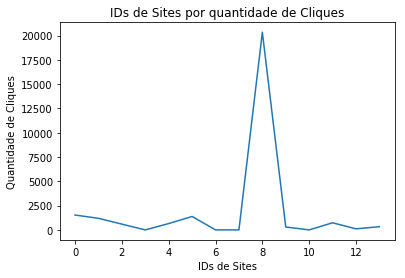

```python
#Criação do Gráfico de Fontes de Tráfego com relação à quantidade de Cliques
traffic = taxi_app.groupby(["Traffic Source ID"], as_index=True)["Click ID"].count()
traffic_labels = padrao_colunas("Traffic Source ID")
traffic_data = dict(zip(traffic_labels,traffic.keys()))
pt.plot(traffic_labels, traffic.get_values());
pt.title("IDs de Sites por quantidade de Cliques");
pt.xlabel("IDs de Sites");
pt.ylabel("Quantidade de Cliques");
```

```python
#Amostragem da legenda dos Valores do eixo X
print("Legenda dos Valores:")
for i in traffic_data:
    print("Índice {0}: Site ID {1}.".format(i, traffic_data[i]))
```

```
Legenda dos Valores:
Índice 0: Site ID 06305dce-21d8-4412-bc81-6b1f5ecf63c9.
Índice 1: Site ID 0bab9113-87a4-4da8-8a46-c2d1f18ce4c8.
Índice 2: Site ID 5cff49a9-50d7-4272-917f-614a822124de.
Índice 3: Site ID 69a52e19-d624-497f-a000-ca28df5e28a4.
Índice 4: Site ID 6b3d5dad-15d8-47a2-8109-2a85d80df0fc.
Índice 5: Site ID 7826a798-e3ce-4462-9248-900af565efff.
Índice 6: Site ID 7982181f-6a20-4837-88e2-c332622f3d2a.
Índice 7: Site ID 874d21e1-a1f5-4848-8825-fcc21b1edc83.
Índice 8: Site ID 9a2a1675-584d-491d-9fc9-aeaa674c6e2d.
Índice 9: Site ID 9ac698ae-4a3f-4023-b49a-d5cb19a6ed88.
Índice 10: Site ID d51c988f-915a-417f-acb8-872e5063a70e.
Índice 11: Site ID db6c7a1a-450f-4cdf-bf3c-d7efd71f35cf.
Índice 12: Site ID e2c04fed-16d0-4dcd-9787-7e23def8e1aa.
Índice 13: Site ID fe41c4f2-e6d0-463a-b046-cb97fe33f0de.
```

Apesar de ter um pico no ID **9a2a1675-584d-491d-9fc9-aeaa674c6e2d**, o atributo não poderia ser considerado uma boa fonte de base para a elaboraão da próxima campanha, pelo fato de ter pouca visibilidade imediata.

```python
taxi_app.groupby(["Site ID", "Country"]).count()
```

| Site ID | Country | Postback Timestamp | Click ID | Transaction ID | Traffic Source ID | OS | Isp | Connection Type | IP |
| --- | --- | --- | --- | --- | --- | --- | --- | --- | --- |
| $PUBID | Brazil | 2 | 2 | 2 | 2 | 2 | 2 | 2 | 2 |
| 020e7tf2xda5tcwbdz8u_WIRY_8pqvhc | Brazil | 1 | 1 | 1 | 1 | 1 | 1 | 1 | 1 |
| 030ajw3b178_5728_2232452_10_462_40529462 | Brazil | 1 | 1 | 1 | 1 | 1 | 1 | 1 | 1 |
| 060a0653a269937s119629 | Brazil | 1 | 1 | 1 | 1 | 1 | 1 | 1 | 1 |
| 0c0wmwc54265_526_1278_T_144_T_3_1_6595 | Brazil | 1 | 1 | 1 | 1 | 1 | 1 | 1 | 1 |
| 0e0aa2ca1412 | Brazil | 1 | 1 | 1 | 1 | 1 | 1 | 1 | 1 |
| 1 | Brazil | 4 | 4 | 4 | 4 | 4 | 4 | 4 | 4 |
| 1.ct | United States | 1 | 1 | 1 | 1 | 1 | 1 | 1 | 1 |
| 100e7tf0xyzjx4c5e3ub_APDT_f040vz | Brazil | 1 | 1 | 1 | 1 | 1 | 1 | 1 | 1 |
| 101487 | Brazil | 215 | 215 | 215 | 215 | 215 | 215 | 215 | 215 |
| 105185 | Argentina | 4 | 4 | 4 | 4 | 4 | 4 | 4 | 4 |
|  | Brazil | 66 | 66 | 66 | 66 | 66 | 66 | 66 | 66 |
|  | Colombia | 7 | 7 | 7 | 7 | 7 | 7 | 7 | 7 |
|  | Costa Rica | 1 | 1 | 1 | 1 | 1 | 1 | 1 | 1 |
|  | Ecuador | 7 | 7 | 7 | 7 | 7 | 7 | 7 | 7 |
|  | Mexico | 3 | 3 | 3 | 3 | 3 | 3 | 3 | 3 |
|  | Peru | 7 | 7 | 7 | 7 | 7 | 7 | 7 | 7 |
|  | Spain | 1 | 1 | 1 | 1 | 1 | 1 | 1 | 1 |
| 106564 | Brazil | 12 | 12 | 12 | 12 | 12 | 12 | 12 | 12 |
| 110ajw67178_6761_499_20530499 | Brazil | 1 | 1 | 1 | 1 | 1 | 1 | 1 | 1 |
| 110wmwae4265_526_1278_T_144_T_3_1_6512 | Brazil | 1 | 1 | 1 | 1 | 1 | 1 | 1 | 1 |
| 12088 | Brazil | 4585 | 4585 | 4585 | 4585 | 4585 | 4585 | 4585 | 4585 |
| 1234 | United States | 2 | 2 | 2 | 2 | 2 | 2 | 2 | 2 |
| 14780 | Brazil | 268 | 268 | 268 | 268 | 268 | 268 | 268 | 268 |
| 150dqv1142508 | Brazil | 1 | 1 | 1 | 1 | 1 | 1 | 1 | 1 |
| 157389 | Brazil | 1 | 1 | 1 | 1 | 1 | 1 | 1 | 1 |
| 16549 | Brazil | 194 | 194 | 194 | 194 | 194 | 194 | 194 | 194 |
| 170a09d7329178000 | Brazil | 2 | 2 | 2 | 2 | 2 | 2 | 2 | 2 |
| 170ay3d7329178000 | Brazil | 1 | 1 | 1 | 1 | 1 | 1 | 1 | 1 |
| 173758 | Brazil | 44 | 44 | 44 | 44 | 44 | 44 | 44 | 44 |
| ... | ... | ... | ... | ... | ... | ... | ... | ... | ... |
| mob6bb1a6f9456a9e16 | Brazil | 1 | 1 | 1 | 1 | 1 | 1 | 1 | 1 |
| mob731fd8dd79c59059 | Brazil | 2 | 2 | 2 | 2 | 2 | 2 | 2 | 2 |
| mob7738ed5fe0d17593 | Brazil | 1 | 1 | 1 | 1 | 1 | 1 | 1 | 1 |
| mob79f9930f1ae7ddf1 | Brazil | 4 | 4 | 4 | 4 | 4 | 4 | 4 | 4 |
| mob938c8f618a5a9a56 | Brazil | 1 | 1 | 1 | 1 | 1 | 1 | 1 | 1 |
| mob9b5d1723e4d1a4af | Brazil | 1 | 1 | 1 | 1 | 1 | 1 | 1 | 1 |
| mob9f56013f88194e9d | Brazil | 2 | 2 | 2 | 2 | 2 | 2 | 2 | 2 |
| mobaeef607112c86351 | Brazil | 3 | 3 | 3 | 3 | 3 | 3 | 3 | 3 |
| mobaef59b7cefd2cbd0 | Brazil | 2 | 2 | 2 | 2 | 2 | 2 | 2 | 2 |
| mobb6ae7f328ba789d7 | Brazil | 1 | 1 | 1 | 1 | 1 | 1 | 1 | 1 |
| mobb87dbac675c6d95e | Brazil | 3 | 3 | 3 | 3 | 3 | 3 | 3 | 3 |
| mobbfb574dcc9fa2a96 | Brazil | 5 | 5 | 5 | 5 | 5 | 5 | 5 | 5 |
| mobc2fab6c9d8287feb | Brazil | 18 | 18 | 18 | 18 | 18 | 18 | 18 | 18 |
| mobc58dffb0b0b196a3 | Brazil | 2 | 2 | 2 | 2 | 2 | 2 | 2 | 2 |
| mobc9a83a135983afb3 | Brazil | 1 | 1 | 1 | 1 | 1 | 1 | 1 | 1 |
| mobcc94ca07f79a8996 | Brazil | 2 | 2 | 2 | 2 | 2 | 2 | 2 | 2 |
| mobcd12eb53a1015d7d | Brazil | 1 | 1 | 1 | 1 | 1 | 1 | 1 | 1 |
| mobd0ea5728b9f9882c | Brazil | 1 | 1 | 1 | 1 | 1 | 1 | 1 | 1 |
| mobd58871942e755652 | Brazil | 1 | 1 | 1 | 1 | 1 | 1 | 1 | 1 |
| mobdb714ebe577ec91c | Brazil | 1 | 1 | 1 | 1 | 1 | 1 | 1 | 1 |
| mobdf3bd29b5a5865db | Brazil | 1 | 1 | 1 | 1 | 1 | 1 | 1 | 1 |
| mobe4950c637736a587 | Brazil | 21 | 21 | 21 | 21 | 21 | 21 | 21 | 21 |
| mobee9b97986146bddf | Brazil | 3 | 3 | 3 | 3 | 3 | 3 | 3 | 3 |
| mobf11497131b304f83 | Brazil | 2 | 2 | 2 | 2 | 2 | 2 | 2 | 2 |
| mobf3b1ea5e19ffa9ff | Brazil | 2 | 2 | 2 | 2 | 2 | 2 | 2 | 2 |
| mobf4544a94f912cef8 | Brazil | 1 | 1 | 1 | 1 | 1 | 1 | 1 | 1 |
| mobfc4b7d800a726d15 | Brazil | 1 | 1 | 1 | 1 | 1 | 1 | 1 | 1 |
| xapnt17x | Brazil | 1 | 1 | 1 | 1 | 1 | 1 | 1 | 1 |
| {affiliate_id} | Brazil | 1 | 1 | 1 | 1 | 1 | 1 | 1 | 1 |
| {sub_publisher} | Brazil | 41 | 41 | 41 | 41 | 41 | 41 | 41 | 41 |

584 rows × 8 columns

Mesmo com a comparação entre o atributo **Country**, observa-se a presença de valores considerados *lixos*, por não ter relação direta com o formato dos dados presentes no **Site ID**, como *{affiliate_id}* e *1.ct*. Por isso, conclui-se que esse atributo não é válido para seu uso na elaboração da próxima campanha.

## Conclusão

Com base nos dados analisados, e nas observações aferidas, conclui-se que os melhores atributos para serem melhor estudados , e assim possíveis de serem utilizados na próxima campanha, são *Country*, *Transation ID*, *OS*, *Connection Type* e *Ips*. Esses atributos, com as observações, foram observados minuciosamente e, mesmo após seus tratamentos, possuem uma correlação interessante tanto de forma independente quanto entre si, principalmente se utilizado um atributo em comum como **Click ID** e **Country**. Portanto, podem ser considerados necessários para o estudo e a elaboração da próxima campanha.